# Lab 9: Linear Regression

Daniel Deneau

2021-07-03

```r
library(tidyverse)
library(openintro)
download.file("http://www.openintro.org/stat/data/mlb11.RData", destfile = "mlb11.RData")
load("mlb11.RData")
```

### Exercise 1

I would use a scatterplot. The relationship does look linear, but there are some clouds of points with high runs and lower values of at_bats making the trend a bit weaker. Overall, I would be comfortable using this model to predict the number of runs.

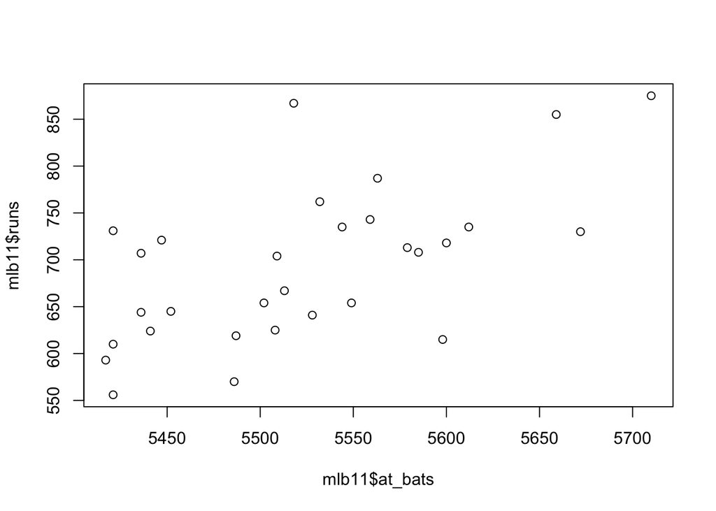

```r
plot(mlb11$at_bats, mlb11$runs)
```

```r
cor(mlb11$runs, mlb11$at_bats)
```

```
## [1] 0.610627
```

```r
mlb11
```

```
##                     team runs at_bats hits homeruns bat_avg strikeouts
## 1          Texas Rangers  855    5659 1599      210   0.283        930
## 2         Boston Red Sox  875    5710 1600      203   0.280       1108
## 3         Detroit Tigers  787    5563 1540      169   0.277       1143
## 4     Kansas City Royals  730    5672 1560      129   0.275       1006
## 5    St. Louis Cardinals  762    5532 1513      162   0.273        978
## 6          New York Mets  718    5600 1477      108   0.264       1085
## 7       New York Yankees  867    5518 1452      222   0.263       1138
## 8      Milwaukee Brewers  721    5447 1422      185   0.261       1083
## 9       Colorado Rockies  735    5544 1429      163   0.258       1201
## 10        Houston Astros  615    5598 1442       95   0.258       1164
## 11     Baltimore Orioles  708    5585 1434      191   0.257       1120
## 12   Los Angeles Dodgers  644    5436 1395      117   0.257       1087
## 13          Chicago Cubs  654    5549 1423      148   0.256       1202
## 14       Cincinnati Reds  735    5612 1438      183   0.256       1250
```

[output cut: 47 more lines]

### Exercise 2

The plot shows a positive linear trend, that is strong with R = 0.61. We would see a stronger correlation if it were not for a cloud of observations towards the left side. The general trend is that the number of runs increases with as at_bat increases.

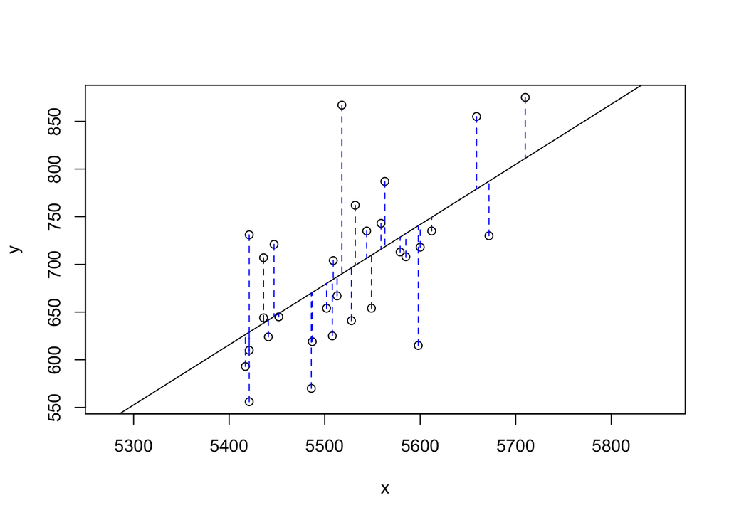

```
## Click two points to make a line.

## Call:
## lm(formula = y ~ x, data = pts)
##
## Coefficients:
## (Intercept)            x
##  -2789.2429       0.6305
##
## Sum of Squares:  123721.9
```

```r
plot_ss(x = mlb11$at_bats, y = mlb11$runs)
```

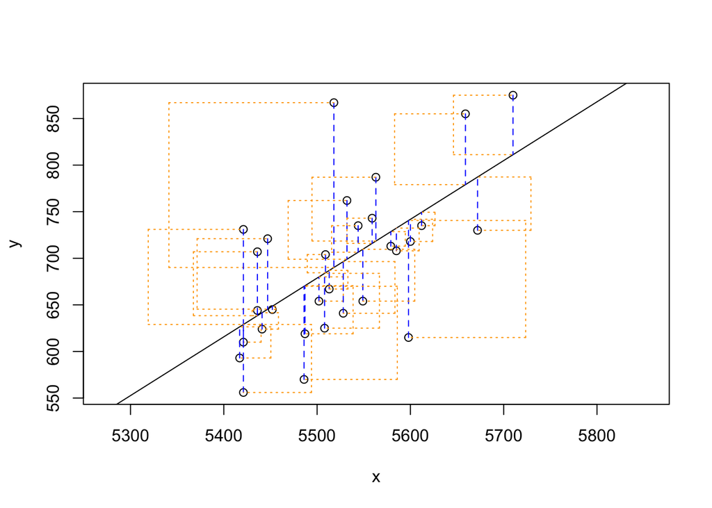

```
## Click two points to make a line.

## Call:
## lm(formula = y ~ x, data = pts)
##
## Coefficients:
## (Intercept)            x
##  -2789.2429       0.6305
##
## Sum of Squares:  123721.9
```

```r
plot_ss(x = mlb11$at_bats, y = mlb11$runs, showSquares = TRUE)
```

### Exercise 3

The smallest sum of squares was 123721.9

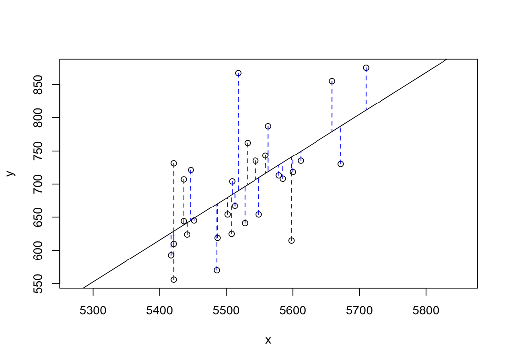

```
## Click two points to make a line.

## Call:
## lm(formula = y ~ x, data = pts)
##
## Coefficients:
## (Intercept)            x
##  -2789.2429       0.6305
##
## Sum of Squares:  123721.9
```

```r
plot_ss(x = mlb11$at_bats, y = mlb11$runs)
```

### Exercise 4

y_hat = 415.2389 + 1.8345*homeruns The slope tells us that the number of runs increases by 1.835 for each increase in the home runs.

```r
m1 <- lm(runs ~ at_bats, data = mlb11)
summary(m1)
```

```
##
## Call:
## lm(formula = runs ~ at_bats, data = mlb11)
##
## Residuals:
##     Min      1Q  Median      3Q     Max
## -125.58  -47.05  -16.59   54.40  176.87
##
## Coefficients:
##               Estimate Std. Error t value Pr(>|t|)
## (Intercept) -2789.2429   853.6957  -3.267 0.002871 **
## at_bats         0.6305     0.1545   4.080 0.000339 ***
## ---
## Signif. codes:  0 '***' 0.001 '**' 0.01 '*' 0.05 '.' 0.1 ' ' 1
##
## Residual standard error: 66.47 on 28 degrees of freedom
## Multiple R-squared:  0.3729, Adjusted R-squared:  0.3505
## F-statistic: 16.65 on 1 and 28 DF,  p-value: 0.0003388
```

```r
m2 <- lm(runs ~ homeruns, data = mlb11)
summary(m2)
```

```
##
## Call:
## lm(formula = runs ~ homeruns, data = mlb11)
##
## Residuals:
##     Min      1Q  Median      3Q     Max
## -91.615 -33.410   3.231  24.292 104.631
##
## Coefficients:
##             Estimate Std. Error t value Pr(>|t|)
## (Intercept) 415.2389    41.6779   9.963 1.04e-10 ***
## homeruns      1.8345     0.2677   6.854 1.90e-07 ***
## ---
## Signif. codes:  0 '***' 0.001 '**' 0.01 '*' 0.05 '.' 0.1 ' ' 1
##
## Residual standard error: 51.29 on 28 degrees of freedom
## Multiple R-squared:  0.6266, Adjusted R-squared:  0.6132
## F-statistic: 46.98 on 1 and 28 DF,  p-value: 1.9e-07
```

### Exercise 5

Using the equation, a team with 5,578 at-bats would have a predicted number of runs of: 728 runs.

```r
y <- -2789.2429 + (0.6305 * 5578)
y
```

```
## [1] 727.6861
```

Using the plotted pair (5579, 713), we see that 728 is an overstimate with the residual being: 728-713 = 15

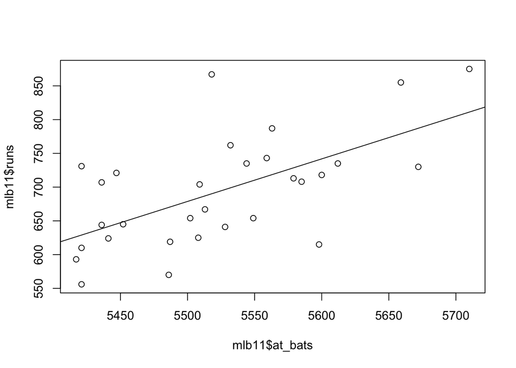

```r
plot(mlb11$runs ~ mlb11$at_bats)
abline(m1)
```

```r
data.frame(mlb11$runs, mlb11$at_bats)
```

```
##    mlb11.runs mlb11.at_bats
## 1         855          5659
## 2         875          5710
## 3         787          5563
## 4         730          5672
## 5         762          5532
## 6         718          5600
## 7         867          5518
## 8         721          5447
## 9         735          5544
## 10        615          5598
## 11        708          5585
## 12        644          5436
## 13        654          5549
## 14        735          5612
```

[output cut: 16 more lines]

```r
728 - 713
```

```
## [1] 15
```

### Excercise 6

There are no obvious patterns, so the relationship could be modeled linearly. We would need to perform a hypothesis test to determine whether the linearity is statistically significant or due to chance.

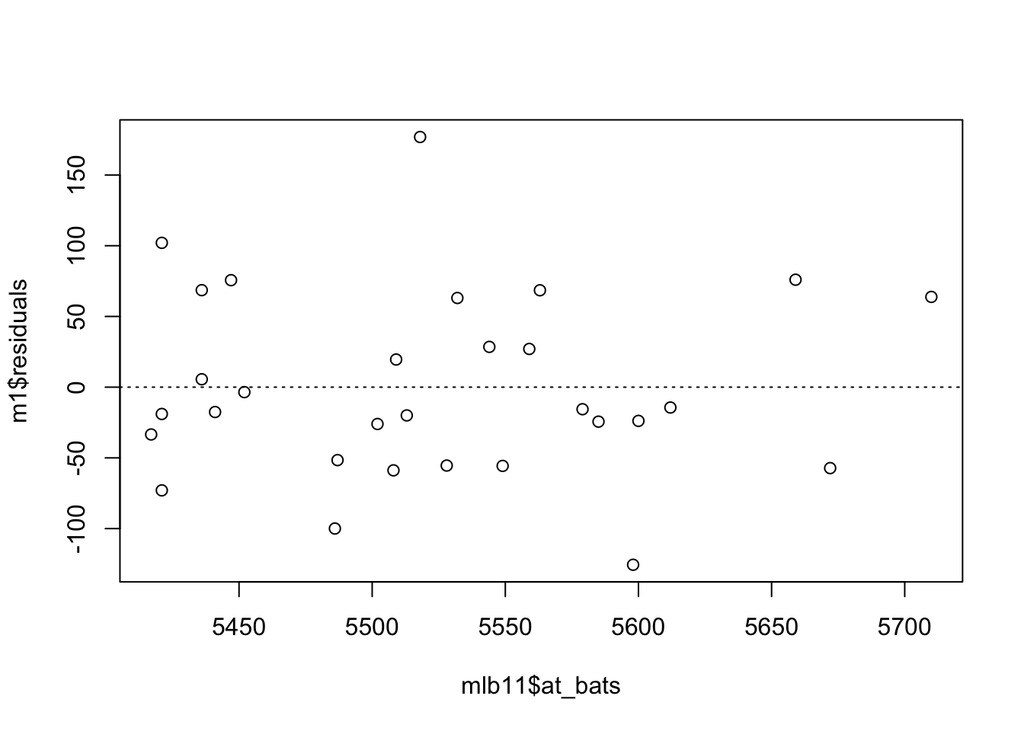

```r
plot(m1$residuals ~ mlb11$at_bats)
abline(h = 0, lty = 3)  # adds a horizontal dashed line at y = 0
```

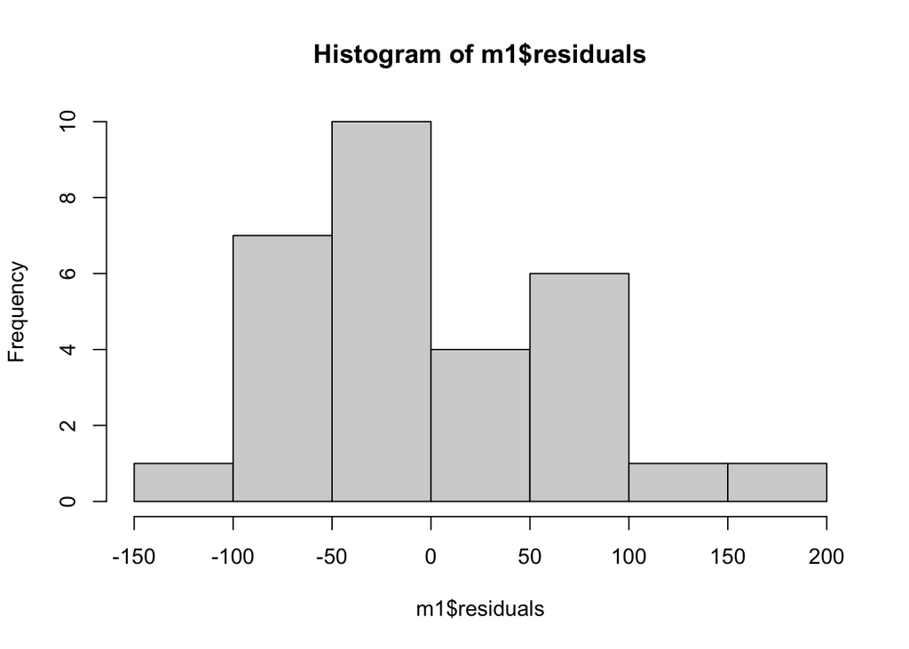

```r
hist(m1$residuals)
```

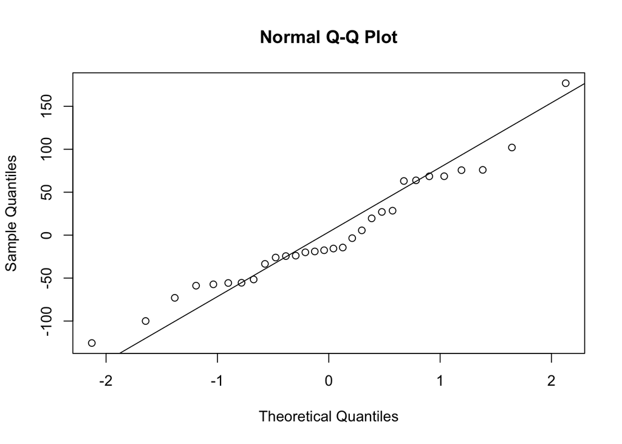

```r
qqnorm(m1$residuals)
qqline(m1$residuals)  # adds diagonal line to the normal prob plot
```

### Exercise 7 The histogram is nearly normal even though the shape is not perfect, and the normal probability plot follows a linear trend closely. So the residual conditions appear to be met.

### Exercise 8

The variability in both plots is not very high at all, so the constant variability condition appears to be met.

### OY0 1

I would like to see if players with less strikeouts have higher run counts. At a glance, there does appear to be a negative linear relationship.

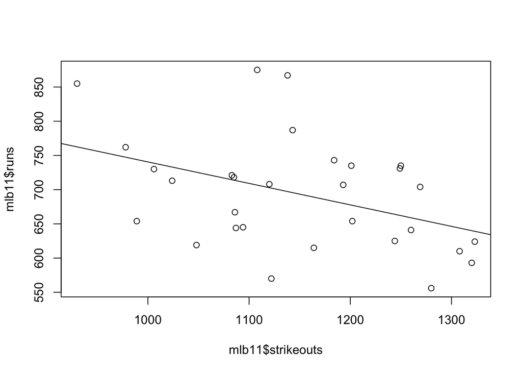

```r
m3 <- lm(runs ~ strikeouts, data = mlb11)
plot(mlb11$runs ~ mlb11$strikeouts)
abline(m3)
```

### OYO 2

Only 16.9% of the variaility in runs is explained by strikeouts, compared to 37.3% for at-bats. So my model does not nearly predict runs at well.

```r
cor(mlb11$runs, mlb11$at_bats)
```

```
## [1] 0.610627
```

```r
cor(mlb11$runs, mlb11$strikeouts)
```

```
## [1] -0.4115312
```

```r
summary(m1)
```

```
##
## Call:
## lm(formula = runs ~ at_bats, data = mlb11)
##
## Residuals:
##     Min      1Q  Median      3Q     Max
## -125.58  -47.05  -16.59   54.40  176.87
##
## Coefficients:
##               Estimate Std. Error t value Pr(>|t|)
## (Intercept) -2789.2429   853.6957  -3.267 0.002871 **
## at_bats         0.6305     0.1545   4.080 0.000339 ***
## ---
## Signif. codes:  0 '***' 0.001 '**' 0.01 '*' 0.05 '.' 0.1 ' ' 1
##
## Residual standard error: 66.47 on 28 degrees of freedom
## Multiple R-squared:  0.3729, Adjusted R-squared:  0.3505
## F-statistic: 16.65 on 1 and 28 DF,  p-value: 0.0003388
```

```r
summary(m3)
```

```
##
## Call:
## lm(formula = runs ~ strikeouts, data = mlb11)
##
## Residuals:
##     Min      1Q  Median      3Q     Max
## -132.27  -46.95  -11.92   55.14  169.76
##
## Coefficients:
##              Estimate Std. Error t value Pr(>|t|)
## (Intercept) 1054.7342   151.7890   6.949 1.49e-07 ***
## strikeouts    -0.3141     0.1315  -2.389   0.0239 *
## ---
## Signif. codes:  0 '***' 0.001 '**' 0.01 '*' 0.05 '.' 0.1 ' ' 1
##
## Residual standard error: 76.5 on 28 degrees of freedom
## Multiple R-squared:  0.1694, Adjusted R-squared:  0.1397
## F-statistic: 5.709 on 1 and 28 DF,  p-value: 0.02386
```

### OYO 3

Batting average appears to best predict runs, with a correlation coefficient of 0.81

```r
m4 <- lm(runs ~ bat_avg, data = mlb11)
plot(mlb11$runs ~ mlb11$bat_avg)
cor(mlb11$runs, mlb11$bat_avg)
```

```
## [1] 0.8099859
```

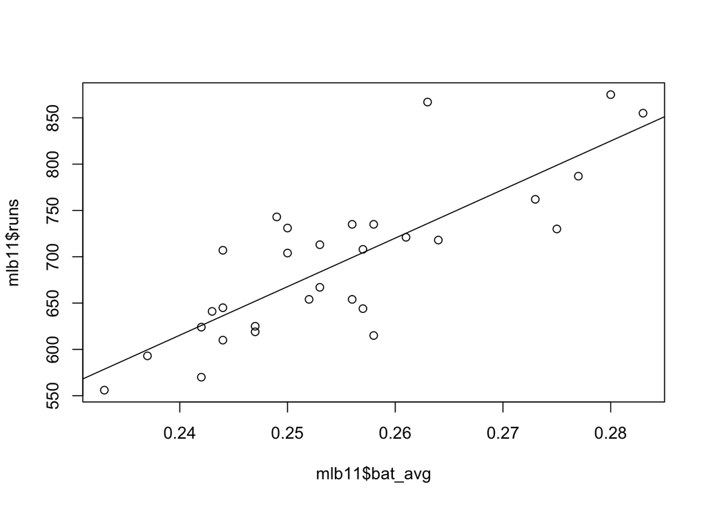

```r
abline(m4)
```

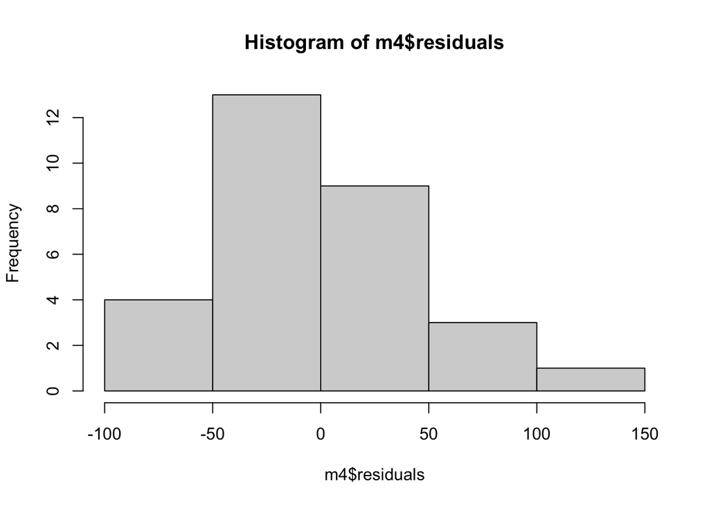

```r
hist(m4$residuals)
```

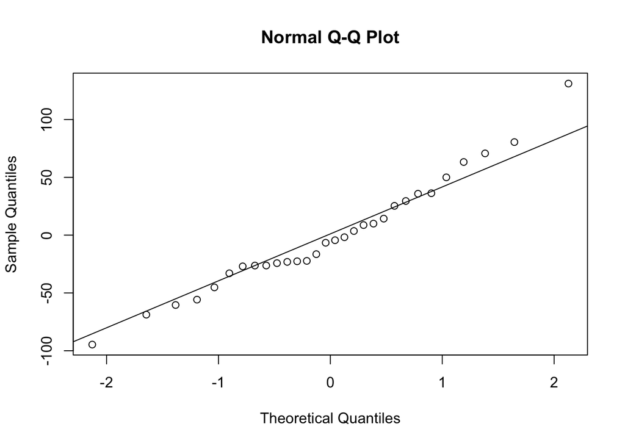

```r
qqnorm(m4$residuals)
qqline(m4$residuals)
```

```r
summary(m4)
```

```
##
## Call:
## lm(formula = runs ~ bat_avg, data = mlb11)
##
## Residuals:
##     Min      1Q  Median      3Q     Max
## -94.676 -26.303  -5.496  28.482 131.113
##
## Coefficients:
##             Estimate Std. Error t value Pr(>|t|)
## (Intercept)   -642.8      183.1  -3.511  0.00153 **
## bat_avg       5242.2      717.3   7.308 5.88e-08 ***
## ---
## Signif. codes:  0 '***' 0.001 '**' 0.01 '*' 0.05 '.' 0.1 ' ' 1
##
## Residual standard error: 49.23 on 28 degrees of freedom
## Multiple R-squared:  0.6561, Adjusted R-squared:  0.6438
## F-statistic: 53.41 on 1 and 28 DF,  p-value: 5.877e-08
```

### OYO 4

All of these variables do seem to be really good predictors for runs, with high correlation coefficients and strong linear trends in their plots. The best predictor is on-base plus slugging. This metric seems to take in account a lot of factors that makes high performing players have a higher value. Therefore the results do not seem surprising.

```r
m_e_1 <- lm(runs ~ new_onbase, data = mlb11)
m_e_2 <- lm(runs ~ new_slug, data = mlb11)
m_e_3 <- lm(runs ~ new_obs, data = mlb11)

plot(mlb11$runs ~ mlb11$new_onbase)
cor(mlb11$runs, mlb11$new_onbase)
```

```
## [1] 0.9214691
```

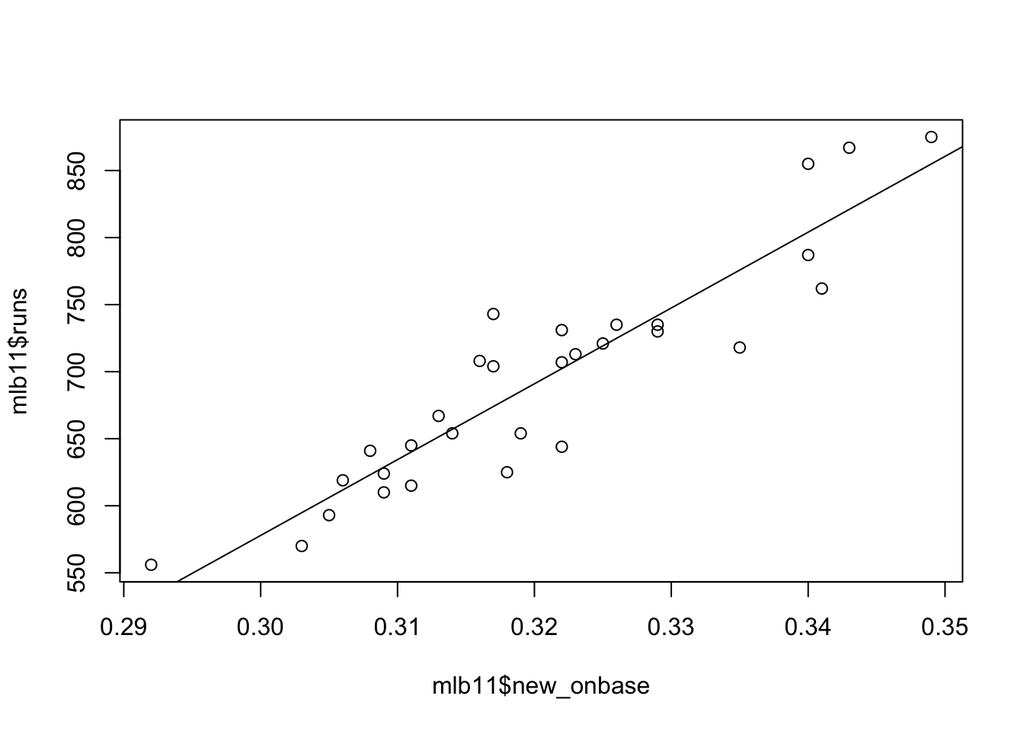

```r
abline(m_e_1)
```

```r
plot(mlb11$runs ~ mlb11$new_slug)
cor(mlb11$runs, mlb11$new_slug)
```

```
## [1] 0.9470324
```

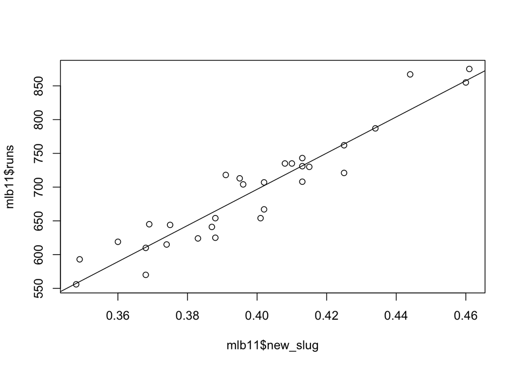

```r
abline(m_e_2)
```

```r
plot(mlb11$runs ~ mlb11$new_obs)
cor(mlb11$runs, mlb11$new_obs)
```

```
## [1] 0.9669163
```

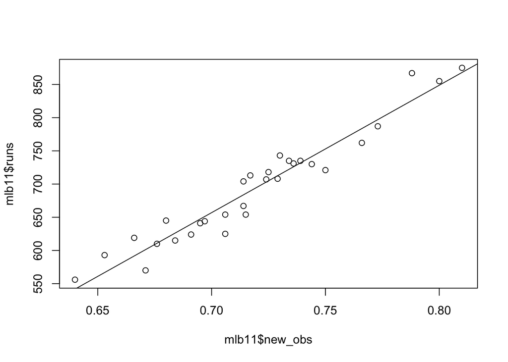

```r
abline(m_e_3)
```

### OYO 5

Linearity: The data does show a linear trend with a strong correlation coefficient.

Nearly Normal Residuals: The histogram of the residuals resembles a normal distribution closely.

Constant Variability: The residual plot shows constant variability, as do the points on the normal probability plot.

Independent Observations: We know from the dataset that each observation is independent.

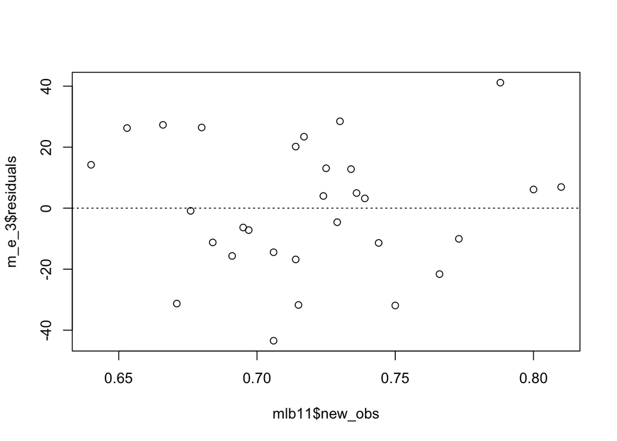

```r
plot(m_e_3$residuals ~ mlb11$new_obs)
abline(h = 0, lty = 3)  # adds a horizontal dashed line at y = 0
```

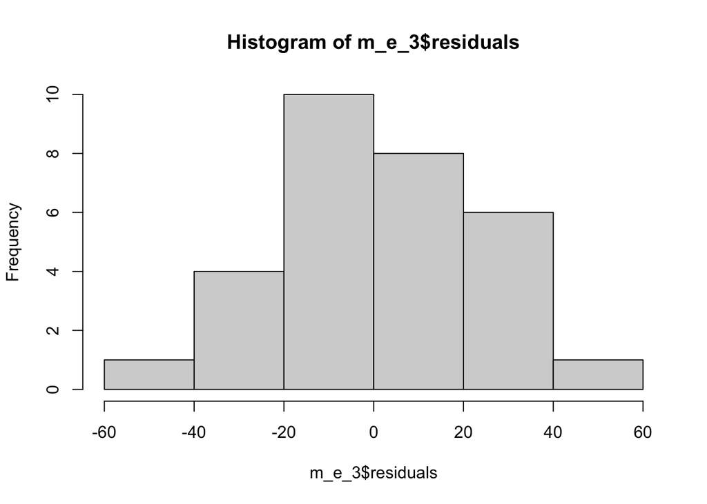

```r
hist(m_e_3$residuals)
```

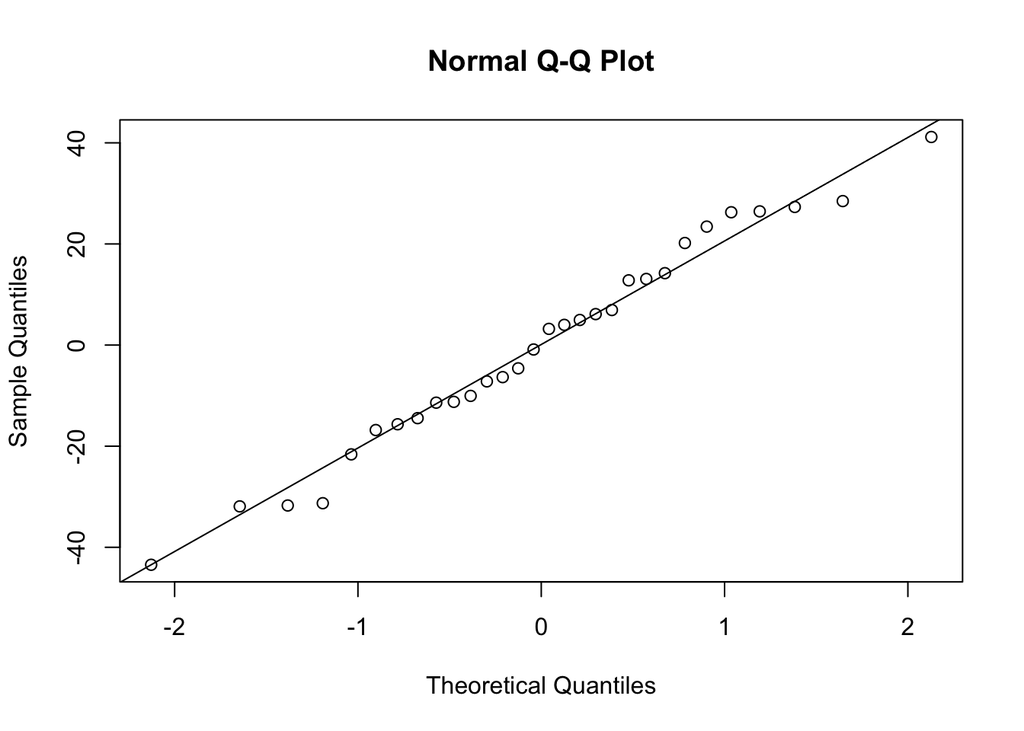

```r
qqnorm(m_e_3$residuals)
qqline(m_e_3$residuals)  # adds diagonal line to the normal prob plot
```

```r
summary(m_e_3)
```

```
##
## Call:
## lm(formula = runs ~ new_obs, data = mlb11)
##
## Residuals:
##     Min      1Q  Median      3Q     Max
## -43.456 -13.690   1.165  13.935  41.156
##
## Coefficients:
##             Estimate Std. Error t value Pr(>|t|)
## (Intercept)  -686.61      68.93  -9.962 1.05e-10 ***
## new_obs      1919.36      95.70  20.057  < 2e-16 ***
## ---
## Signif. codes:  0 '***' 0.001 '**' 0.01 '*' 0.05 '.' 0.1 ' ' 1
##
## Residual standard error: 21.41 on 28 degrees of freedom
## Multiple R-squared:  0.9349, Adjusted R-squared:  0.9326
## F-statistic: 402.3 on 1 and 28 DF,  p-value: < 2.2e-16
```